# Assignment 2

Alison Wu

# Decription of article

The of the most dynamic cell populations found in turmous are leukocytes. They play a very important role in normal breast tissue remodeling during pregnancy and involution. This study performed a gene expression analysis in leukocytes sorted from normal breast tissues, ductal carcinomas in situ (DCIS), and HER2+ and triple negative invasive ductal carcinomas (IDC). It focuses on the immune escape during breast tumor progression.

About the dataset

Source name resected breast tumor Organism Homo sapiens Characteristics tissue of origin: breast (tumor) cell type: CD45+CD3+ T cell breast tumor subtype: DCIS/ IDC/ None

Results from A1 Retrieved dataset(GSE87517) from GEOquery.Checked if there is any duplicated genes and features in the dataset. Since the dataset contains HUGO symbols so I mapped it with ENSEMBL gene id. Gathered all the information from BioManager::useMart and mapped it with our dataset. Only 6 duplicates existed in the mapping therefore I manually filtered out the duplicates by checking them on the ensembl gene portal. Normalized the data and filtered out low counts data. Look at the distribution of the dataset by Boxplot, MDS plot and Density plot. The final coverage of my dataset is 26440 out of 27011 observed values (missing ~2.2% of the dataset)

# Prework

Install all the required packages

```r
if (!requireNamespace("BiocManager", quietly = TRUE))
  install.packages("BiocManager")
if (!requireNamespace("Biobase", quietly = TRUE))
    BiocManager::install("Biobase")
if (!requireNamespace("ComplexHeatmap", quietly = TRUE))
    BiocManager::install("ComplexHeatmap")
if (!requireNamespace("circlize", quietly = TRUE))
    BiocManager::install("circlize")
if (!requireNamespace("gprofiler2", quietly = TRUE))
    install.packages("gprofiler2")
```

Reference the packages

```r
  library(Biobase)
  library(ComplexHeatmap)
  library(circlize)
  library(gprofiler2)
```

# Gene of interest

Look at the most common genes of the same subfamily in our dataset

```r
#Find the genes of interest
#Start with strongest signals
#The most common genes of the same subfamily
rownames(exp_filtered) <- exp_filtered$Feature
genes_sample <- data.frame(lapply(rownames(normalized_data), FUN = function(x){unlist(strsplit(x, "(?=[A-Za-z])(?<=[0-9])|(?=[0-9])(?<=[A-Za-z])", perl=TRUE))[c(1,2)]}))
colnames(genes_sample) <- colnames(exp_filtered)[2:42]
rownames(genes_sample) <- c("subfamily", "num")
genes_sample <- data.frame(t(genes_sample))

summarized_gene_counts <- sort(table(genes_sample$subfamily),decreasing = TRUE)

head(summarized_gene_counts)
```

```
##
##  LOC LINC  ZNF    C  SLC  FAM
## 1355  632  522  477  380  300
```

CD8A - According to Entrez Gene Summary: - CD8A acts as a coreceptor with the T-cell receptor on the T lymphocyte to recognize antigens

```r
#CD8A
dcis_samples <- grep(colnames(normalized_data),
                          pattern="DCIS")
idc_samples <- grep(colnames(normalized_data),
                          pattern="IDC")
normal_samples <- grep(colnames(normalized_data),
                    pattern="N")
gene_of_interest <- "CD8A"

CD8A_dcis_samples <- data.matrix(normalized_data
                       [gene_of_interest,
                         dcis_samples])
colnames(CD8A_dcis_samples) <- c("dcis_samples")
CD8A_idc_samples <- data.matrix(normalized_data
                       [gene_of_interest,
                         idc_samples])
colnames(CD8A_idc_samples) <- c("idc_samples")
CD8A_normal_samples <- data.matrix(normalized_data
                       [gene_of_interest,
                         normal_samples])
colnames(CD8A_normal_samples) <- c("normal_samples")

# DCIS VS Normal
t.test(x=t(CD8A_dcis_samples),y=t(CD8A_normal_samples))
```

```
##
##  Welch Two Sample t-test
##
## data:  t(CD8A_dcis_samples) and t(CD8A_normal_samples)
## t = -0.92393, df = 17.895, p-value = 0.3678
## alternative hypothesis: true difference in means is not equal to 0
## 95 percent confidence interval:
##  -2.4529180  0.9548865
## sample estimates:
## mean of x mean of y
##  4.331695  5.080711
```

```r
# IDC vs Normal
t.test(x=t(CD8A_idc_samples),y=t(CD8A_normal_samples))
```

```
##
##  Welch Two Sample t-test
##
## data:  t(CD8A_idc_samples) and t(CD8A_normal_samples)
## t = -3.8856, df = 26.022, p-value = 0.0006289
## alternative hypothesis: true difference in means is not equal to 0
## 95 percent confidence interval:
##  -3.583839 -1.104006
## sample estimates:
## mean of x mean of y
##  2.736788  5.080711
```

CTLA-4 : immune checkpoint proteins - mentioned in the results of the article

- signaling pathways were upregulated in IDC compared to DCIS
- CTLA-4 were also more abundant in T cells from IDCs than in DCIS,

```r
#CTLA4
gene_of_interest <- "CTLA4"

CTLA4_dcis_samples <- data.matrix(normalized_data
                                 [gene_of_interest,
                                   dcis_samples])
colnames(CTLA4_dcis_samples) <- c("dcis_samples")
CTLA4_idc_samples <- data.matrix(normalized_data
                                [gene_of_interest,
                                  idc_samples])
colnames(CTLA4_idc_samples) <- c("idc_samples")
CTLA4_normal_samples <- data.matrix(normalized_data
                                   [gene_of_interest,
                                     normal_samples])
colnames(CTLA4_normal_samples) <- c("normal_samples")

# DCIS VS Normal
t.test(x=t(CTLA4_dcis_samples),y=t(CTLA4_normal_samples))
```

```
##
##  Welch Two Sample t-test
##
## data:  t(CTLA4_dcis_samples) and t(CTLA4_normal_samples)
## t = 1.4857, df = 13.051, p-value = 0.1611
## alternative hypothesis: true difference in means is not equal to 0
## 95 percent confidence interval:
##  -0.5580282  3.0188473
## sample estimates:
## mean of x mean of y
##  2.339701  1.109291
```

```r
# IDC vs Normal
t.test(x=t(CTLA4_idc_samples),y=t(CTLA4_normal_samples))
```

```
##
##  Welch Two Sample t-test
##
## data:  t(CTLA4_idc_samples) and t(CTLA4_normal_samples)
## t = 3.5966, df = 11.811, p-value = 0.003758
## alternative hypothesis: true difference in means is not equal to 0
## 95 percent confidence interval:
##  1.475537 6.031031
## sample estimates:
## mean of x mean of y
##  4.862575  1.109291
```

# Differential expression analysis

Use edgeR to perform differential expression analysis as edgeR is designed for analyzing RNA-seq data. using Quasi liklihood method to get the estimation of allowing overdispersion and this method can fit data exhibiting overdispersion using fully specified probability models

Design the model for the anaylsis

```r
subtypes <- samples$subtype
model_design <- model.matrix(~ 0 + subtypes)
expressionMatrix <- as.matrix(normalized_data[,1:41])
rownames(expressionMatrix) <- rownames(normalized_data)
colnames(expressionMatrix) <- colnames(normalized_data)[1:41]
minSet <- ExpressionSet(assayData=expressionMatrix)

#Fit the model
fit <- lmFit(minSet, model_design)
```

Take a look at the MDS plot

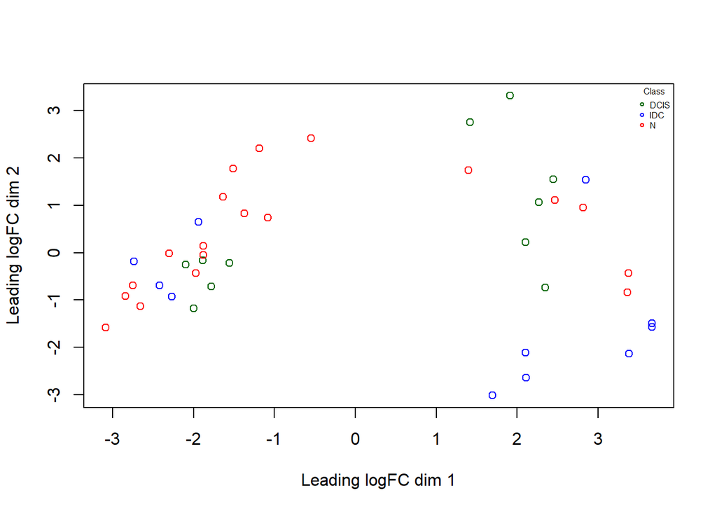

```r
#Normalize the data
dm <-  as.matrix(exp_filtered[,2:42])
rownames(dm) <- exp_filtered$Feature
d <- DGEList(counts=dm, group=samples$subtype)

d <- calcNormFactors(d)



#MDS Plot

plotMDS(d, labels=NULL, pch = 1,
        col= c("darkgreen","blue","red")[factor(samples$subtype)])
legend("topright",
       legend=levels(factor(samples$subtype)),
       pch=c(1), col= c("darkgreen","blue","red"),
       title="Class",
       bty = 'n', cex = 0.5)
```

According to above MDS Plot, setting the magnitude of log-fold change of at least 1 and less than one seems reasonable.

```r
#Estimate Dispersion - our model design.
d <- estimateDisp(d, model_design)

#Fit the model
fit <- glmQLFit(d, model_design)
```

Calculate differential expression

Make a contrast table explicitly comparing normal genes and affected (dcis and idc) genes

```r
#Normal vs all
contrast_normal <- makeContrasts(normalVSall ="subtypesN-(subtypesDCIS +
  subtypesIDC)/2", levels=model_design)



#Get all the results
qlf.normal_vs_all <- glmQLFTest(fit, contrast=contrast_normal)
tt_normal_vs_all <- topTags(qlf.normal_vs_all,n=nrow(d))


#How many gene pass the threshold p-value < 0.05?
length(which(tt_normal_vs_all$table$PValue<0.05))
```

```
## [1] 8066
```

```r
#How many genes pass correction?
#using BH as the adjusted method
length(which(tt_normal_vs_all$table$FDR < 0.01))
```

```
## [1] 2573
```

Plot the heatmap to compare the expressions of normal/ unaffected genes and affected genes.

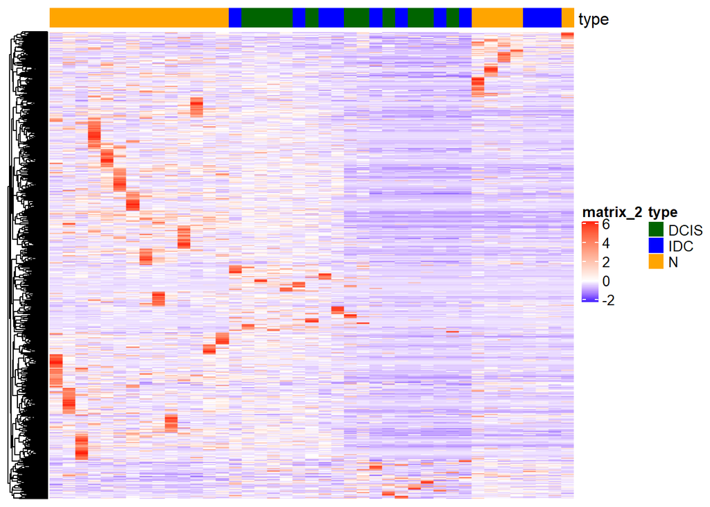

```r
#Heatmap
heatmap_matrix <- normalized_data[,1:ncol(normalized_data)]
rownames(heatmap_matrix) <- rownames(normalized_data)
colnames(heatmap_matrix) <- colnames(normalized_data[,1:ncol(normalized_data)])

top_hits <- rownames(tt_normal_vs_all)[which(tt_normal_vs_all$table$FDR < 0.01)]
heatmap_matrix_tophits <- t(
  scale(t(heatmap_matrix[which(rownames(heatmap_matrix) %in% top_hits),])))
if(min(heatmap_matrix_tophits) == 0){
  heatmap_col = colorRamp2(c( 0, max(heatmap_matrix_tophits)),
                           c( "white", "red"))
} else {
  heatmap_col = colorRamp2(c(min(heatmap_matrix_tophits), 0, max(heatmap_matrix_tophits)), c("blue", "white", "red"))
}
current_heatmap <- Heatmap(as.matrix(heatmap_matrix_tophits),
                           cluster_rows = TRUE,  show_row_dend = TRUE,
                           cluster_columns = TRUE,show_column_dend = FALSE,
                           col=heatmap_col,show_column_names = FALSE,
                           show_row_names = FALSE,show_heatmap_legend = TRUE)
n_colours <- c("darkgreen","blue","orange")
names(n_colours) <- unique(samples$subtype)
n <- HeatmapAnnotation(df=data.frame(type = samples$subtype), col = list(type = n_colours))
current_heatmap <- Heatmap(as.matrix(heatmap_matrix_tophits),
                           cluster_rows = TRUE,  show_row_dend = TRUE,
                           cluster_columns = TRUE,show_column_dend = FALSE,
                           col=heatmap_col,show_column_names = FALSE,
                           show_row_names = FALSE,show_heatmap_legend = TRUE,
                           top_annotation = n)
current_heatmap
```

Up regualted genes

```r
diff_exp <- merge(exp[,1:1],tt_normal_vs_all, by.x=1, by.y = 0)
diff_exp[,"rank"] <- -log(diff_exp$PValue,base =10) * sign(diff_exp$logFC)
length(which(tt_normal_vs_all$table$PValue <= 0.05
                       & tt_normal_vs_all$table$logFC >= 1))
```

```
## [1] 5942
```

```r
up_genes <- diff_exp$x[which(diff_exp$PValue <= 0.05 & diff_exp$logFC >= 1)]
```

Down regulated genes

```r
length(which(tt_normal_vs_all$table$PValue < 0.05
                       & tt_normal_vs_all$table$logFC <= -1))
```

```
## [1] 2123
```

```r
down_genes <- diff_exp$x[which(diff_exp$PValue < 0.05 & diff_exp$logFC <= -1)]
```

Save all genes lists

```r
write.table(x=up_genes,
            file=file.path("up_genes.txt"),sep = "\t",
            row.names = FALSE,col.names = FALSE,quote = FALSE)
write.table(x=down_genes,
            file=file.path("down_genes.txt"),sep = "\t",
            row.names = FALSE,col.names = FALSE,quote = FALSE)
write.table(x=data.frame(genename= diff_exp$x,F_stat= diff_exp$rank),
            file=file.path("ranked_genelist.txt"),sep = "\t",
            row.names = FALSE,col.names = FALSE,quote = FALSE)
```

# Thresholded Over-representation analysis

To perform a thresholded gene set enrichment analysis, we can either go on the web interface (https://biit.cs.ut.ee/gprofiler/gost) to run g:Profiler or use the gprofiler2 package.

Using the function gost() to retrieve the functional enrichment analysis of gene lists. The annotation data and the version of the annotation I am using is:

GO:MF – releases/2019-07-01

GO:CC – releases/2019-07-01

GO:BP – releases/2019-07-01

KEGG – KEGG FTP Release 2019-09-30

REAC – annotations: ensembl

classes: 2019-10-2

WP – 20190910

TF – annotations: TRANSFAC Release 2019.1

classes: v2

MIRNA – Release 7.0

HPA – annotations: HPA website: 2017-12-01

classes: script: 2018-03-19

CORUM – 03.09.2018 Corum 3.0

HP – hpo.annotations.monthly #157

```r
#Upregualted genes
up_gpro <- gost(up_genes, organism = "hsapiens", ordered_query = FALSE,
     multi_query = FALSE, significant = TRUE, exclude_iea = FALSE,
     measure_underrepresentation = FALSE, evcodes = FALSE,
     user_threshold = 0.05, correction_method = c("fdr"),
     domain_scope = c("annotated"),
     custom_bg = NULL, numeric_ns = "", sources = NULL,
     as_short_link = FALSE)

head(up_gpro$result)
```

```
##     query significant      p_value term_size query_size intersection_size
## 1 query_1        TRUE 8.599586e-05     16622       4383              3781
## 2 query_1        TRUE 8.599586e-05     16622       4383              3781
## 3 query_1        TRUE 1.950758e-04     13260       4383              3066
## 4 query_1        TRUE 1.950758e-04      4641       4383              1155
## 5 query_1        TRUE 2.033616e-04      8420       4383              2006
## 6 query_1        TRUE 3.662015e-04     14265       4383              3275
##   precision    recall     term_id source
## 1 0.8626512 0.2274696 TF:M01240_0     TF
## 2 0.8626512 0.2274696   TF:M01240     TF
## 3 0.6995209 0.2312217 TF:M01240_1     TF
## 4 0.2635181 0.2488688 TF:M09729_1     TF
## 5 0.4576774 0.2382423 TF:M04106_1     TF
## 6 0.7472051 0.2295829 TF:M00986_0     TF
##                                                term_name effective_domain_size
## 1           Factor: BEN; motif: CAGCGRNV; match class: 0                 19887
## 2                           Factor: BEN; motif: CAGCGRNV                 19887
## 3           Factor: BEN; motif: CAGCGRNV; match class: 1                 19887
## 4       Factor: LUMAN; motif: CYCAGCYYCY; match class: 1                 19887
## 5 Factor: RUNX2; motif: NRACCGCAAACCGCAN; match class: 1                 19887
## 6       Factor: Churchill; motif: CGGGNN; match class: 0                 19887
##   source_order     parents
## 1          429   TF:M01240
## 2          428   TF:M00000
## 3          430 TF:M01240_0
## 4         4072 TF:M09729_0
## 5         6112 TF:M04106_0
## 6          726   TF:M00986
```

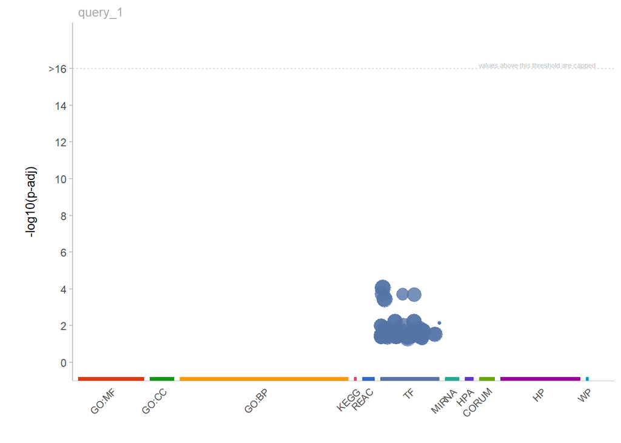

```r
#Plot
gostplot(up_gpro, capped = TRUE, interactive = FALSE)
```

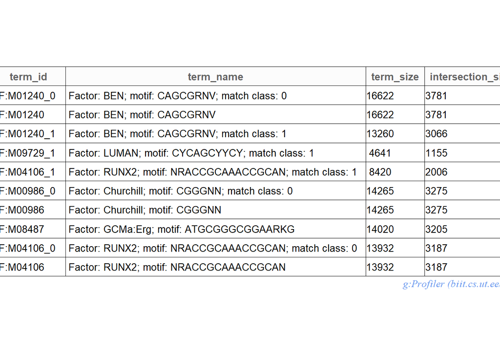

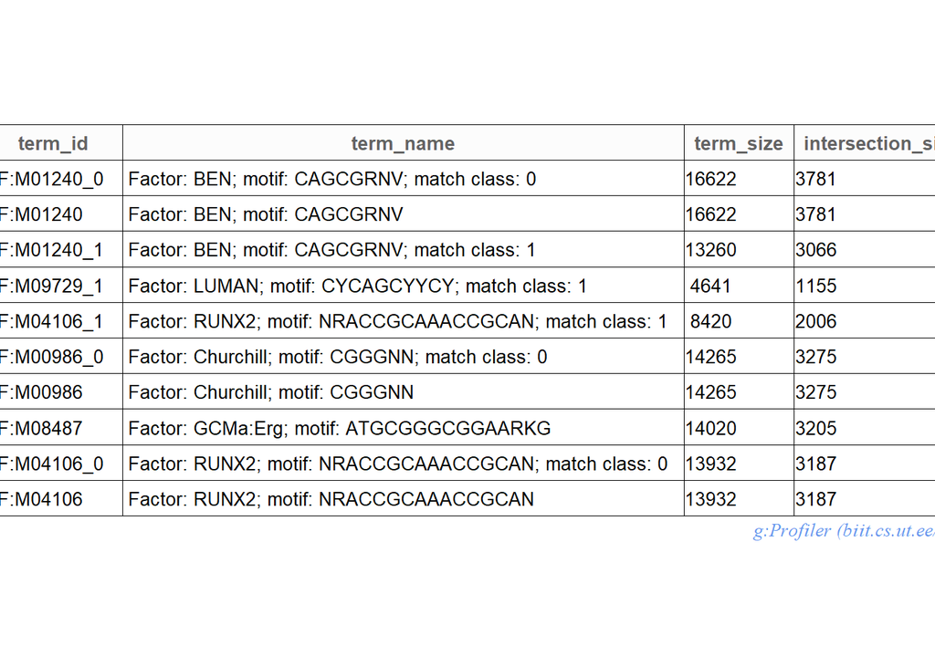

```r
#View all in a chart of upregulated genes instead
publish_gosttable(up_gpro, highlight_terms = up_gpro$result[c(1:10),],
                  use_colors = TRUE,
                  show_columns = c("source", "term_name", "term_size", "intersection_size"),
                  filename = NULL)
```

```r
#Downregulated genes
down_gpro <- gost(down_genes, organism = "hsapiens", ordered_query = FALSE,
                multi_query = FALSE, significant = TRUE, exclude_iea = FALSE,
                measure_underrepresentation = FALSE, evcodes = FALSE,
                user_threshold = 0.05, correction_method = c("fdr"),
                domain_scope = c("annotated"),
                custom_bg = NULL, numeric_ns = "", sources = NULL,
                as_short_link = FALSE)
head(down_gpro$result)
```

```
##     query significant      p_value term_size query_size intersection_size
## 1 query_1        TRUE 7.625172e-04      1121       1466               142
## 2 query_1        TRUE 2.429320e-03      1217       1466               148
## 3 query_1        TRUE 6.657958e-03       797       1466               103
## 4 query_1        TRUE 2.432283e-05     17069       1516              1430
## 5 query_1        TRUE 6.711700e-05     17004       1516              1422
## 6 query_1        TRUE 6.711700e-05      9699       1516               876
##    precision     recall    term_id source
## 1 0.09686221 0.12667261 GO:0071345  GO:BP
## 2 0.10095498 0.12161052 GO:0034097  GO:BP
## 3 0.07025921 0.12923463 GO:0019221  GO:BP
## 4 0.94327177 0.08377761 GO:0005623  GO:CC
## 5 0.93799472 0.08362738 GO:0044464  GO:CC
## 6 0.57783641 0.09031859 GO:0044446  GO:CC
##                                term_name effective_domain_size source_order
## 1 cellular response to cytokine stimulus                 17847        19858
## 2                   response to cytokine                 17847         9761
## 3    cytokine-mediated signaling pathway                 17847         6545
## 4                                   cell                 18842          300
## 5                              cell part                 18842         2403
## 6           intracellular organelle part                 18842         2386
##                              parents
## 1             GO:0034097, GO:0071310
## 2                         GO:0010033
## 3             GO:0007166, GO:0071345
## 4                         GO:0005575
## 5             GO:0005575, GO:0005623
## 6 GO:0043229, GO:0044424, GO:0044422
```

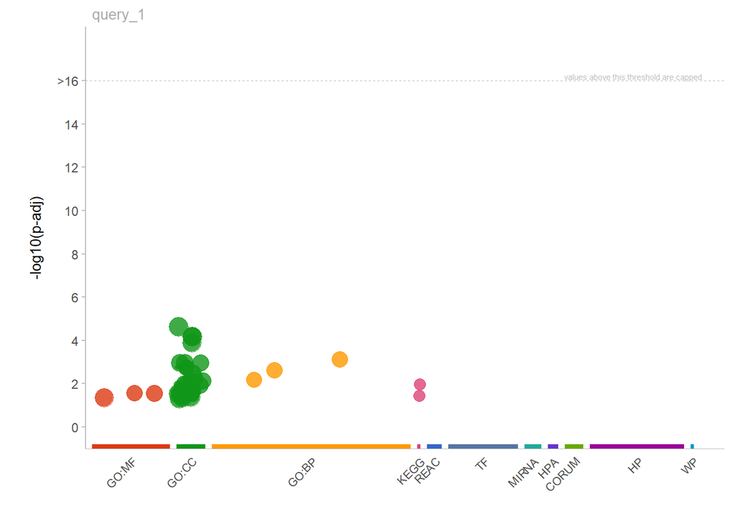

```r
#Plot
gostplot(down_gpro, capped = TRUE, interactive = FALSE)
```

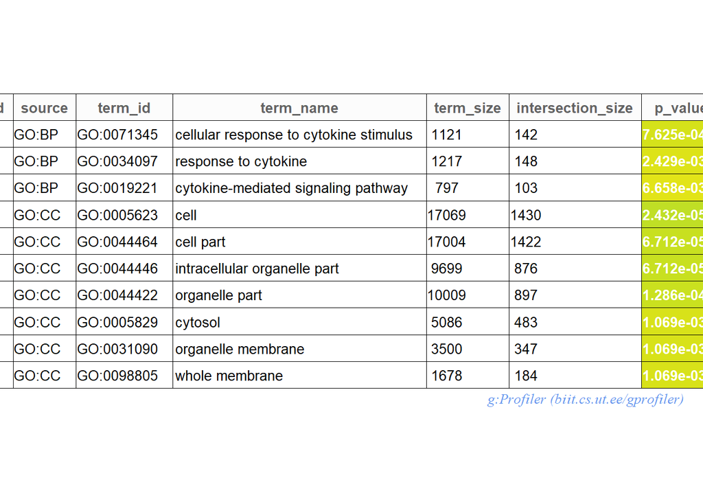

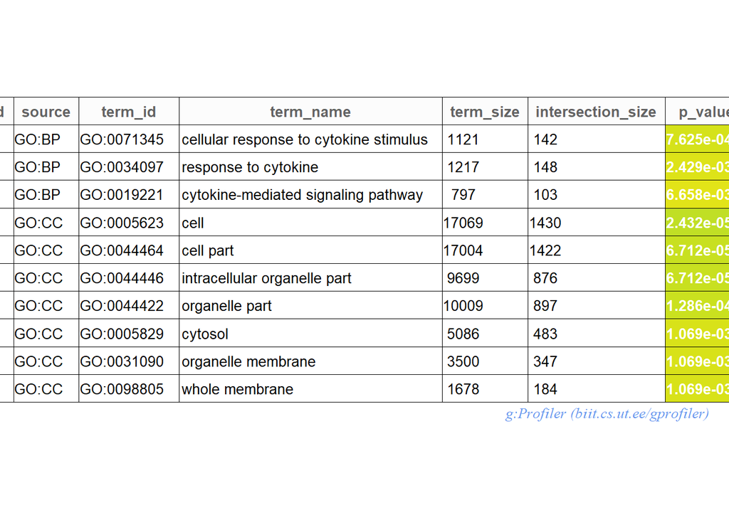

```r
publish_gosttable(down_gpro, highlight_terms = down_gpro$result[c(1:10),],
                        use_colors = TRUE,
                        show_columns = c("source", "term_name", "term_size", "intersection_size"),
                        filename = NULL)
```